# Exploring the Palmer Penguins Dataset

Olivia Hagedoorn

## Introduction

The Palmer Penguins dataset contains measurements of penguins observed near Palmer Station in Antarctica. It includes three species: Adelie, Chinstrap, and Gentoo, along with information about the islands where they were observed, their sex, and physical measurements such as bill length, bill depth, flipper length, and body mass. The goal of this analysis is to explore how physical measurements differ between male and female penguins and among the three species. I will also examine which species are found on each island and use statistical tests to evaluate differences in selected measurements.

### Number of columns and data types

```r
# Display the dimensions of the dataset.
dim(penguins)
```

```
## [1] 344   8
```

```r
# Count the number of columns.
ncol(penguins)
```

```
## [1] 8
```

```r
# Inspect column names and data types.
str(penguins)
```

```
## tibble [344 × 8] (S3: tbl_df/tbl/data.frame)
##  $ species          : Factor w/ 3 levels "Adelie","Chinstrap",..: 1 1 1 1 1 1 1 1 1 1 ...
##  $ island           : Factor w/ 3 levels "Biscoe","Dream",..: 3 3 3 3 3 3 3 3 3 3 ...
##  $ bill_length_mm   : num [1:344] 39.1 39.5 40.3 NA 36.7 39.3 38.9 39.2 34.1 42 ...
##  $ bill_depth_mm    : num [1:344] 18.7 17.4 18 NA 19.3 20.6 17.8 19.6 18.1 20.2 ...
##  $ flipper_length_mm: int [1:344] 181 186 195 NA 193 190 181 195 193 190 ...
##  $ body_mass_g      : int [1:344] 3750 3800 3250 NA 3450 3650 3625 4675 3475 4250 ...
##  $ sex              : Factor w/ 2 levels "female","male": 2 1 1 NA 1 2 1 2 NA NA ...
##  $ year             : int [1:344] 2007 2007 2007 2007 2007 2007 2007 2007 2007 2007 ...
```

```r
# Give one example of each data type present.
# Numeric examples: bill_length_mm and bill_depth_mm
# Integer examples: flipper_length_mm, body_mass_g, and year
# Factor examples: species, island, and sex
```

The dataset contains eight columns. The columns include numeric, integer, and factor data types.

### Number of penguins

```r
# Count all rows in the dataset.
nrow(penguins)
```

```
## [1] 344
```

There are 344 penguin records in the original dataset.

### Sex representation

```r
# Count penguins by sex, including missing values.
table(penguins$sex, useNA = "ifany")
```

```
##
## female   male   <NA>
##    165    168     11
```

```r
# Create separate dataframes for male and female penguins.
pmale <- penguins %>%
  filter(sex == "male")

pfemale <- penguins %>%
  filter(sex == "female")

# Compare the number of records in each dataframe.
nrow(pmale)
```

```
## [1] 168
```

```r
nrow(pfemale)
```

```
## [1] 165
```

The dataset contains 168 male penguins and 165 female penguins. There are also 11 records with missing sex information. Therefore, the recorded male and female counts are similar but not exactly equal.

### Species representation

```r
# Count the number of records for each species.
table(penguins$species)
```

```
##
##    Adelie Chinstrap    Gentoo
##       152        68       124
```

```r
# Create separate dataframes for each species.
pAdel <- penguins %>%
  filter(species == "Adelie")

pChin <- penguins %>%
  filter(species == "Chinstrap")

pGen <- penguins %>%
  filter(species == "Gentoo")

# Compare the number of records.
nrow(pAdel)
```

```
## [1] 152
```

```r
nrow(pChin)
```

```
## [1] 68
```

```r
nrow(pGen)
```

```
## [1] 124
```

The dataset contains 152 Adelie, 68 Chinstrap, and 124 Gentoo penguins. The species are not equally represented.

### Island representation

```r
# Count the number of penguins from each island.
table(penguins$island)
```

```
##
##    Biscoe     Dream Torgersen
##       168       124        52
```

```r
# Create separate dataframes for each island.
iBis <- penguins %>%
  filter(island == "Biscoe")

iDream <- penguins %>%
  filter(island == "Dream")

iTorg <- penguins %>%
  filter(island == "Torgersen")

# Compare the number of records.
nrow(iBis)
```

```
## [1] 168
```

```r
nrow(iDream)
```

```
## [1] 124
```

```r
nrow(iTorg)
```

```
## [1] 52
```

Biscoe has 168 penguins, Dream has 124, and Torgersen has 52. Therefore, the islands are not equally represented.

### Final Sex - Part A

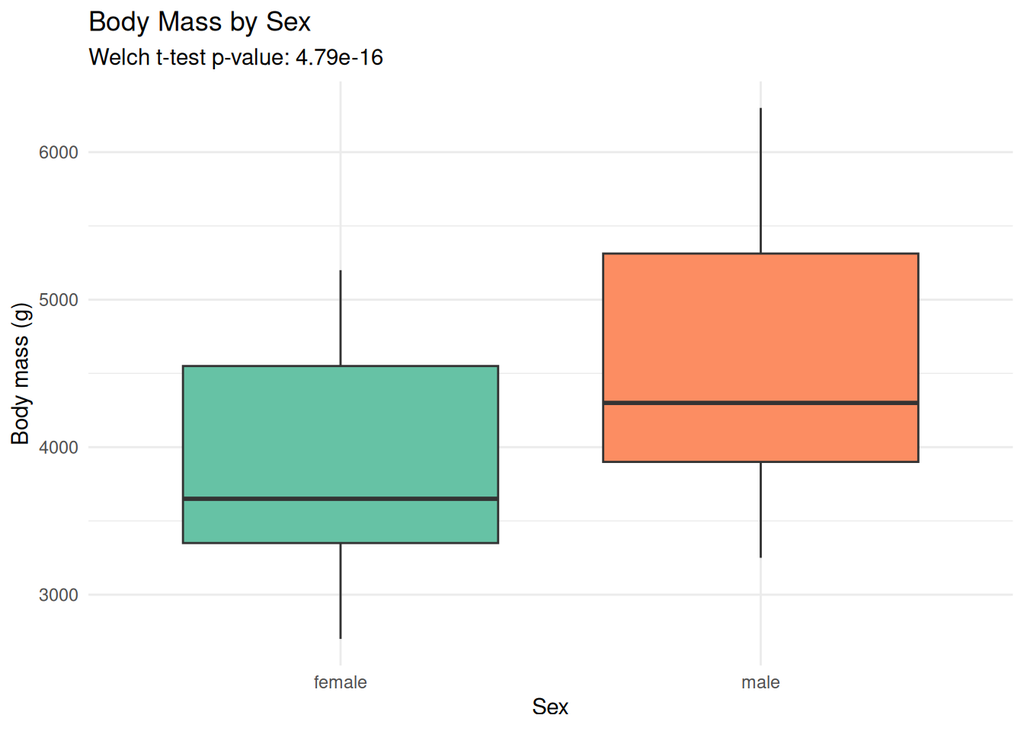

```r
sex_data <- penguins %>%
  filter(!is.na(sex), !is.na(body_mass_g))

sex_test <- t.test(body_mass_g ~ sex, data = sex_data)
sex_p <- sex_test$p.value

FINALsex <- ggplot(sex_data, aes(x = sex, y = body_mass_g, fill = sex)) +
  geom_boxplot() +
  labs(
    title = "Body Mass by Sex",
    x = "Sex",
    y = "Body mass (g)",
    subtitle = paste("Welch t-test p-value:", signif(sex_p, 3))
  ) +
  scale_fill_brewer(palette = "Set2") +
  theme_minimal() +
  theme(legend.position = "none")

FINALsex
```

```r
sex_test
```

```
##
##  Welch Two Sample t-test
##
## data:  body_mass_g by sex
## t = -8.5545, df = 323.9, p-value = 4.794e-16
## alternative hypothesis: true difference in means between group female and group male is not equal to 0
## 95 percent confidence interval:
##  -840.5783 -526.2453
## sample estimates:
## mean in group female   mean in group male
##             3862.273             4545.685
```

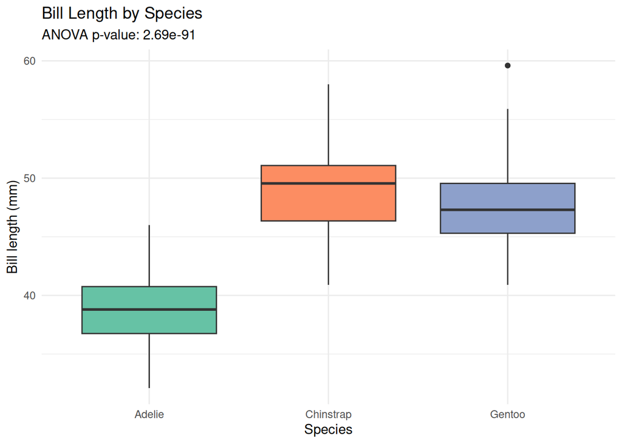

```r
species_data <- penguins %>%
  filter(!is.na(species), !is.na(bill_length_mm))

species_test <- aov(bill_length_mm ~ species, data = species_data)
species_summary <- summary(species_test)
species_p <- species_summary[[1]][["Pr(>F)"]][1]

FINALspecies <- ggplot(
  species_data,
  aes(x = species, y = bill_length_mm, fill = species)
) +
  geom_boxplot() +
  labs(
    title = "Bill Length by Species",
    x = "Species",
    y = "Bill length (mm)",
    subtitle = paste("ANOVA p-value:", signif(species_p, 3))
  ) +
  scale_fill_brewer(palette = "Set2") +
  theme_minimal() +
  theme(legend.position = "none")

FINALspecies
```

```r
species_summary
```

```
##              Df Sum Sq Mean Sq F value Pr(>F)
## species       2   7194    3597   410.6 <2e-16 ***
## Residuals   339   2970       9
## ---
## Signif. codes:  0 '***' 0.001 '**' 0.01 '*' 0.05 '.' 0.1 ' ' 1
```

A one way ANOVA tested whether mean bill length differed among Adelie, Chinstrap, and Gentoo penguins. The test produced an F statistic of 410.6 and a p-value below 2×10⁻¹⁶. Because the p value is below 0.05, the results provide strong evidence that mean bill length differs among the three species. The ANOVA does not identify which specific species differ from one another.

### Final Island — Part C

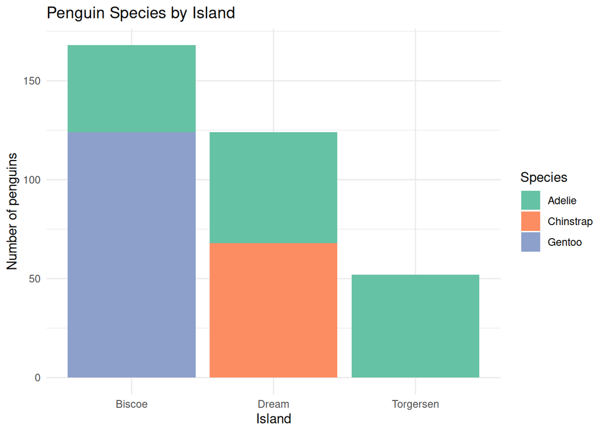

```r
FINALisland <- ggplot(penguins, aes(x = island, fill = species)) +
  geom_bar() +
  labs(
    title = "Penguin Species by Island",
    x = "Island",
    y = "Number of penguins",
    fill = "Species"
  ) +
  scale_fill_brewer(palette = "Set2") +
  theme_minimal()

FINALisland
```